# BF design analysis for SP13 replication

[Guillermo Montero-Melis](https://www.mpi.nl/people/montero-melis-guillermo)

02/09/2019

# 1 Setup workspace

```r
library("knitr")
library("tidyverse")  # ggplot2, dplyr, readr, purrr, etc
library("boot")       # for inv.logit()
library("BFDA")
```

Load posterior estimates from `brms` model fitted to original data:

```r
# read and convert to vector
beta_post <- read_csv("sims_etc/beta_posterior.csv") %>%
  pull(1)
```

# 2 BFDA using effect size based on original study

## 2.1 Simulate hypothetical studies under estimated effect size

We use `type = "abtest"` for the binomial model. Note that as our expected effect size (i.e., the input for `expected.ES` argument) we use the posterior from our `brms` model fit to the original data (see `reanalysis_original.Rmd`).

```r
# # Under alternative hypothesis H1
# sim.H1 <- BFDA.sim(expected.ES = beta_post,  # posterior of original becomes prior
#                    type = "abtest",
#                    # prior,  # unsure about this parameter!
#                    n.min=60, n.max=300, alternative="greater", boundary=Inf, B=1000,
#                    options.sample = list(effecttype = "logOR"),
#                    verbose=TRUE, cores=1, stepsize = 20)

# Save/load to/from disk
# write_rds(sim.H1, "sims_etc/sim_H1.rds")
sim.H1 <- read_rds("sims_etc/sim_H1.rds")
sim.H1
```

```
##
## Bayes Factor Design Analysis
## --------------------------------
## Test type: abtest
## Number of simulations: 1000
## Stopping boundaries (evidential thresholds): 0; Inf
## Directionality of H1 analysis prior: greater
## Minimum n: 60
## Maximum n: 300
## Design: sequential
## Simulated true effect size (random): logOR = 0.15; 25%/75% quantile = [0.12; 0.18]
```

```r
# # Under null hypothesis H0
# sim.H0 <- BFDA.sim(expected.ES = 0,  # no effect
#                    type = "abtest",
#                    # prior,  # unsure about this parameter!
#                    n.min=60, n.max=300, alternative="greater", boundary=Inf, B=1000,
#                    options.sample = list(effecttype = "logOR"),
#                    verbose=TRUE, cores=1, stepsize = 20)

# Save/load to/from disk
# write_rds(sim.H0, "sims_etc/sim_H0.rds")
sim.H0 <- read_rds("sims_etc/sim_H0.rds")
sim.H0
```

```
##
## Bayes Factor Design Analysis
## --------------------------------
## Test type: abtest
## Number of simulations: 1000
## Stopping boundaries (evidential thresholds): 0; Inf
## Directionality of H1 analysis prior: greater
## Minimum n: 60
## Maximum n: 300
## Design: sequential
## Simulated true effect size (fixed): logOR = 0
```

## 2.2 Fixed-n design

The amount of conclusive evidence we obtain at N=180 is vanishingly small!

```r
BFDA.analyze(sim.H1, design="fixed", n=180, boundary=6)
```

```
## 4.5% showed evidence for H1 (BF > 6)
## 80% were inconclusive (0.1667 < BF < 6)
## 15.5% showed evidence for H0 (BF < 0.1667)
```

```r
BFDA.analyze(sim.H0, design="fixed", n=180, boundary=6)
```

```
## 0.5% showed evidence for H1 (BF > 6)
## 58.8% were inconclusive (0.1667 < BF < 6)
## 40.7% showed evidence for H0 (BF < 0.1667)
```

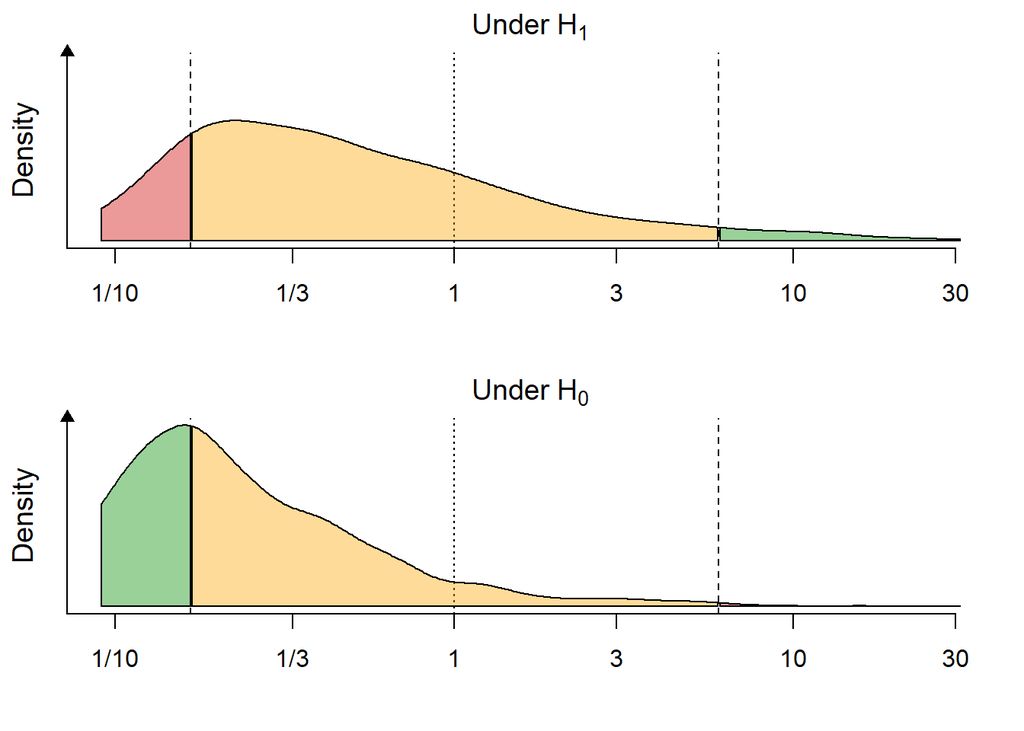

```r
evDens(BFDA.H1=sim.H1, BFDA.H0=sim.H0, n=180, boundary=c(1/6, 6), xlim=c(1/11, 31))
```

## 2.3 Sequential design

A sequential design (well, with maxN = 300) still remains largely inconclusive.

### 2.3.1 Under H1

```r
BFDA.analyze(sim.H1, design="sequential", n.min=60, n.max=300, boundary=6)
```

```
##                                outcome percentage
## 1 Studies terminating at n.max (n=300)      51.5%
## 2    Studies terminating at a boundary      48.5%
## 3       --> Terminating at H1 boundary      15.4%
## 4       --> Terminating at H0 boundary      33.1%
##
## Of 51.5% of studies terminating at n.max (n=300):
## 1.5% showed evidence for H1 (BF > 3)
## 34.7% were inconclusive (3 > BF > 1/3)
## 15.3% showed evidence for H0 (BF < 1/3)
##
## Average sample number (ASN) at stopping point (both boundary hits and n.max): n = 228
##
## Sample number quantiles (50/80/90/95%) at stopping point:
## 50% 80% 90% 95%
## 300 300 300 300
```

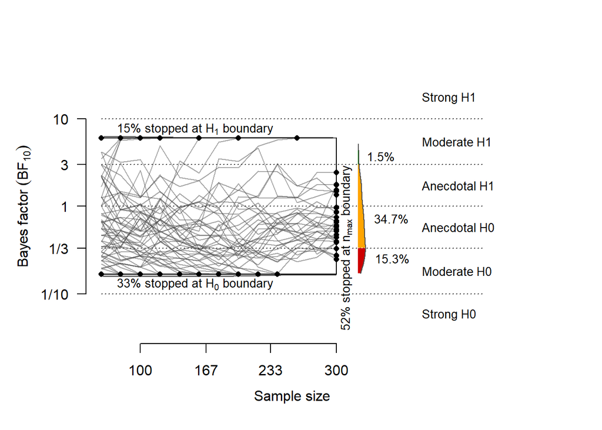

```r
plot(sim.H1, n.min=60, boundary=c(1/6, 6))
```

### 2.3.2 Under H0

```r
BFDA.analyze(sim.H0, design="sequential", n.min=60, n.max=300, boundary=6)
```

```
##                                outcome percentage
## 1 Studies terminating at n.max (n=300)      29.2%
## 2    Studies terminating at a boundary      70.8%
## 3       --> Terminating at H1 boundary         3%
## 4       --> Terminating at H0 boundary      67.8%
##
## Of 29.2% of studies terminating at n.max (n=300):
## 0.4% showed evidence for H1 (BF > 3)
## 15.9% were inconclusive (3 > BF > 1/3)
## 12.9% showed evidence for H0 (BF < 1/3)
##
## Average sample number (ASN) at stopping point (both boundary hits and n.max): n = 187
##
## Sample number quantiles (50/80/90/95%) at stopping point:
## 50% 80% 90% 95%
## 180 300 300 300
```

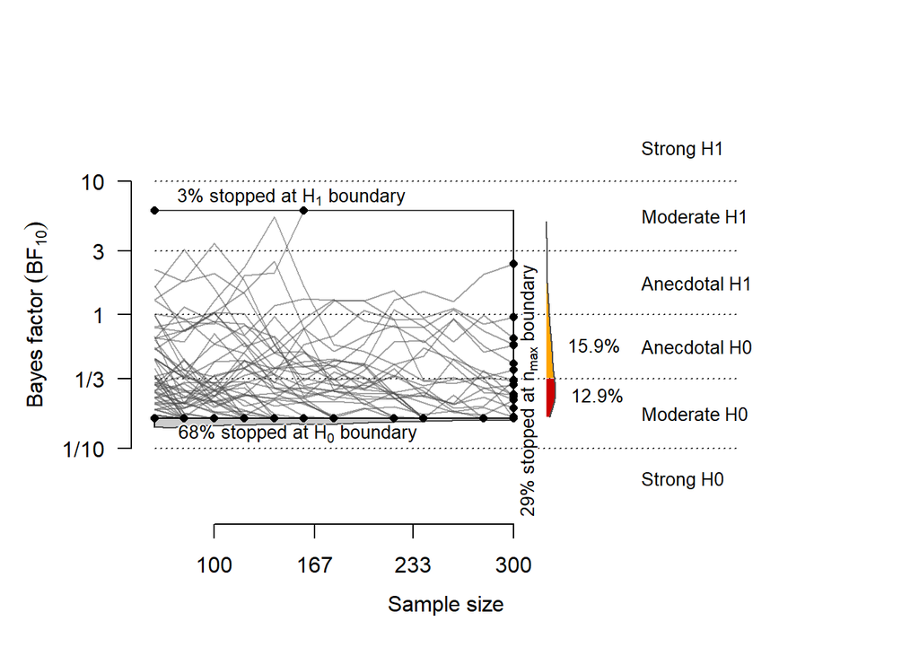

```r
plot(sim.H0, n.min=60, boundary=c(1/6, 6))
```

## 2.4 Find N to achieve power = .80

The N necessary to achieve 80% power is way out there (not even on the map)!

```r
SSD(sim.H1, power=.80, boundary=c(1/6, 6))
```

```
## A >= 80% (actual: NA%) power achieved at n = NA
## This setting implies long-term rates of:
## NA% inconclusive results and
##    NA% false-negative results.
```

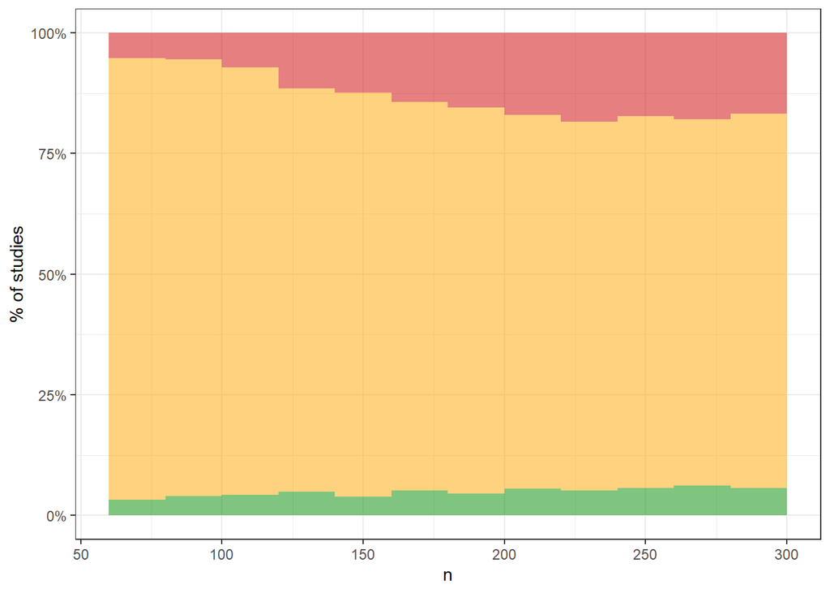

## 2.5 Conclusion

Even though the interaction effect came out as very robust in the brms analysis, the current design analysis indicates that we’d need a prohibitively large N to achieve an efficient design that allows for strong inference.

Why is this the case?

# 3 Why is N so absurdly large?

MAN = [BFDA manual](https://rawgit.com/nicebread/BFDA/master/package/doc/BFDA_manual.html)

The ES is specified using the `expected.ES` argument in the `BFDA::BFDA.sim()` function. However, which metric is used to specify the ES depends on the type of design we are analyzing (see `type` argument):

For t-tests, ES is provided as Cohen’s $d$ (see MAN). Cohen’s $d$ is a standardized measure of the difference between two means. In essence, it is computed as the ratio of the difference in mean and the SD, see https://en.wikiversity.org/wiki/Cohen%27s_d. This metric thus takes into account the robustness, rather than the magnitude, of the effect. An effect can be “small but robust”.

For the AB test, in contrast, you use an “odds ratio, a log odds ratio, a relative risk, or an absolute risk to define a design prior on the population effect size” (MAN). Because the effect is essentially defined as a change in probability (with a corresponding transformation, e.g. into log-odds space), the mean effect and the variance are completely dependent on one another. For a binomially distributed variable $Y \sim B(n,p)$, $E[Y] = np$ and $Var[Y] = np(1-p)$.

In other words, when we provide a log-odds for the effect size, we are providing both an estimate of the mean and the variance of $Y$. Importantly, note that for any given $n$, the variance of $Y$ is highest if $p=0.5$, and it is in general high for values near $p=.5$ (see figure below for n=1, i.e. under the Bernoulli distribution). Since the effect we are estimating corresponds to $p \approx .54$ (i.e., close to .5), the variance will be quite high.

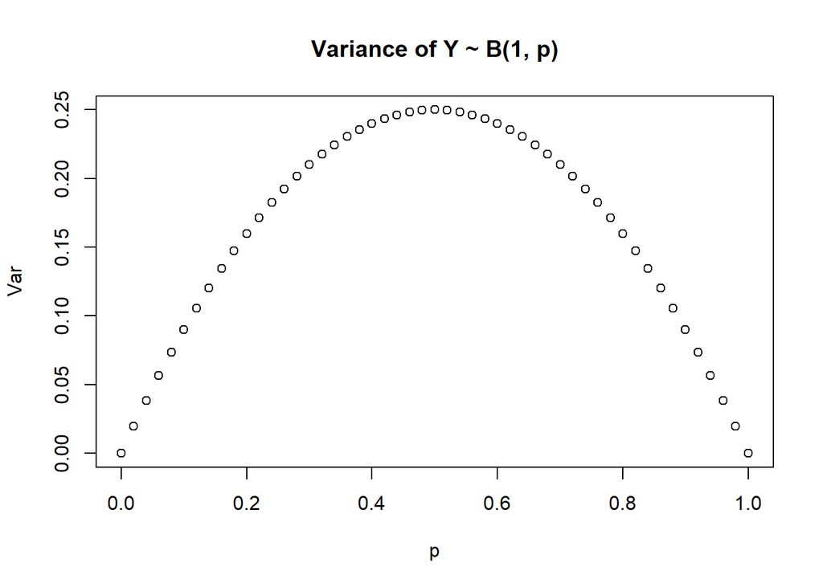

```r
# For n=1:
p <- seq(0, 1, .02)
Var <- p*(1-p)
plot(p, Var, main = "Variance of Y ~ B(1, p)")
```

In conclusion, a small effect in log-odds also has large associated variance. This explains why we would need very high N to “plan for compelling evidence” given the effect size in the original study.

# 4 BFDA using a *minimum effect size of interest* + prior based on original study

We modify our BFDA in the following way:

1. We set the expected effect size to a *minimum effect size of interest*, which we define independently of the estimates from the original data. We plan for a study that is able to find a small effect of, say, 0.5 log-odds (considered “small” in the literature).
2. We use as the `prior` argument the posterior distribution of the model parameter of interest (the interaction/interference effect) based on our re-analysis of the original data.

## 4.1 Simulate hypothetical studies under *minimum effect size* and prior based on original study

```r
# We use `type = "abtest"` for the binomial model.
# # Under alternative hypothesis H1
# sim.H1_05 <- BFDA.sim(expected.ES = 0.5,  # minimum ES of interest
#                       type = "abtest",
#                       prior=list("normal",
#                                  list(prior.mean = mean(beta_post),
#                                       prior.variance = var(beta_post))),
#                       options.sample = list(effecttype = "logOR"),
#                       n.min=60, n.max=300, stepsize = 20, boundary=Inf,
#                       alternative="greater",
#                       B=2000, verbose=TRUE, cores=1)

# [1] "Simulation started at 2019-08-14 13:57:04"
# [1] "Simulation finished at 2019-08-14 14:09:03"
# Duration: Time difference of 11.98412 mins

# Save/load to/from disk:

# write_rds(sim.H1_05, "sims_etc/sim_H1_05.rds")
sim.H1_05 <- read_rds("sims_etc/sim_H1_05.rds")
sim.H1_05
```

```
##
## Bayes Factor Design Analysis
## --------------------------------
## Test type: abtest
## Number of simulations: 2000
## Stopping boundaries (evidential thresholds): 0; Inf
## Directionality of H1 analysis prior: greater
## Minimum n: 60
## Maximum n: 300
## Design: sequential
## Simulated true effect size (fixed): logOR = 0.5
```

```r
# # Under null hypothesis H0
# sim.H0_05 <- BFDA.sim(expected.ES = 0,  # no effect
#                       type = "abtest",
#                       prior=list("normal",
#                                  list(prior.mean = mean(beta_post),
#                                       prior.variance = var(beta_post))),
#                       options.sample = list(effecttype = "logOR"),
#                       n.min=60, n.max=300, stepsize = 20, boundary=Inf,
#                       alternative="greater",
#                       B=2000, verbose=TRUE, cores=1)

# [1] "Simulation started at 2019-08-14 14:11:03"
# [1] "Simulation finished at 2019-08-14 14:23:18"
# Duration: Time difference of 12.24495 mins

# Save/load to/from disk:

# write_rds(sim.H0_05, "sims_etc/sim_H0_05.rds")
sim.H0_05 <- read_rds("sims_etc/sim_H0_05.rds")
sim.H0_05
```

```
##
## Bayes Factor Design Analysis
## --------------------------------
## Test type: abtest
## Number of simulations: 2000
## Stopping boundaries (evidential thresholds): 0; Inf
## Directionality of H1 analysis prior: greater
## Minimum n: 60
## Maximum n: 300
## Design: sequential
## Simulated true effect size (fixed): logOR = 0
```

## 4.2 Sequential design

### 4.2.1 Under H1

```r
BFDA.analyze(sim.H1_05, design="sequential", n.min=60, n.max=300, boundary=6)
```

```
##                                outcome percentage
## 1 Studies terminating at n.max (n=300)      23.9%
## 2    Studies terminating at a boundary        76%
## 3       --> Terminating at H1 boundary        76%
## 4       --> Terminating at H0 boundary         0%
##
## Of 23.9% of studies terminating at n.max (n=300):
## 16.1% showed evidence for H1 (BF > 3)
## 7.9% were inconclusive (3 > BF > 1/3)
## 0% showed evidence for H0 (BF < 1/3)
##
## Average sample number (ASN) at stopping point (both boundary hits and n.max): n = 230
##
## Sample number quantiles (50/80/90/95%) at stopping point:
## 50% 80% 90% 95%
## 240 300 300 300
```

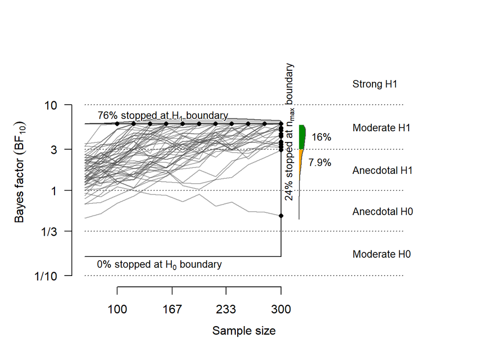

```r
plot(sim.H1_05, n.min=60, boundary=c(1/6, 6))
```

### 4.2.2 Under H0

```r
BFDA.analyze(sim.H0_05, design="sequential", n.min=60, n.max=300, boundary=6)
```

```
##                                outcome percentage
## 1 Studies terminating at n.max (n=300)      91.8%
## 2    Studies terminating at a boundary       8.2%
## 3       --> Terminating at H1 boundary       0.8%
## 4       --> Terminating at H0 boundary       7.4%
##
## Of 91.8% of studies terminating at n.max (n=300):
## 3.9% showed evidence for H1 (BF > 3)
## 73.5% were inconclusive (3 > BF > 1/3)
## 14.4% showed evidence for H0 (BF < 1/3)
##
## Average sample number (ASN) at stopping point (both boundary hits and n.max): n = 295
##
## Sample number quantiles (50/80/90/95%) at stopping point:
## 50% 80% 90% 95%
## 300 300 300 300
```

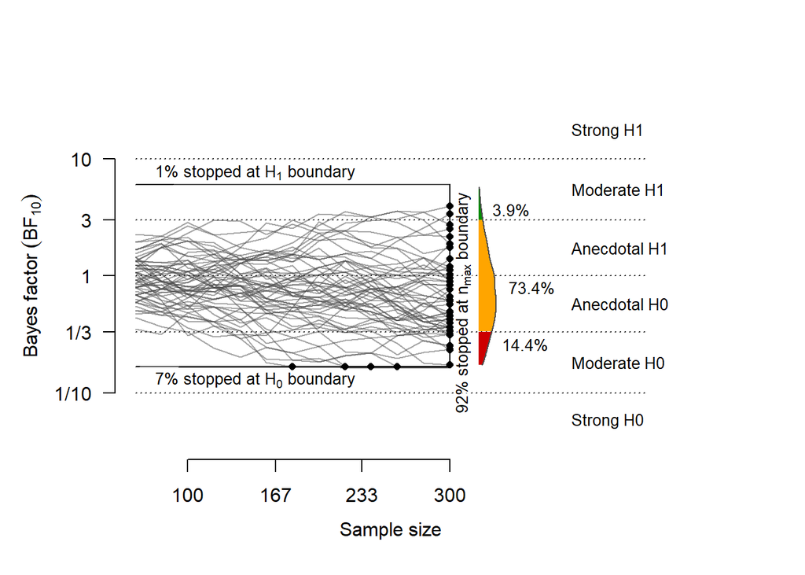

```r
plot(sim.H0_05, n.min=60, boundary=c(1/6, 6))
```

## 4.3 Sequential design with reasonable max N (=140)

### 4.3.1 Under H1

```r
BFDA.analyze(sim.H1_05, design="sequential", n.min=60, n.max=140, boundary=6)
```

```
##                                outcome percentage
## 1 Studies terminating at n.max (n=140)      87.2%
## 2    Studies terminating at a boundary      12.8%
## 3       --> Terminating at H1 boundary      12.8%
## 4       --> Terminating at H0 boundary         0%
##
## Of 87.2% of studies terminating at n.max (n=140):
## 36.5% showed evidence for H1 (BF > 3)
## 50.6% were inconclusive (3 > BF > 1/3)
## 0% showed evidence for H0 (BF < 1/3)
##
## Average sample number (ASN) at stopping point (both boundary hits and n.max): n = 139
##
## Sample number quantiles (50/80/90/95%) at stopping point:
## 50% 80% 90% 95%
## 140 140 140 140
```

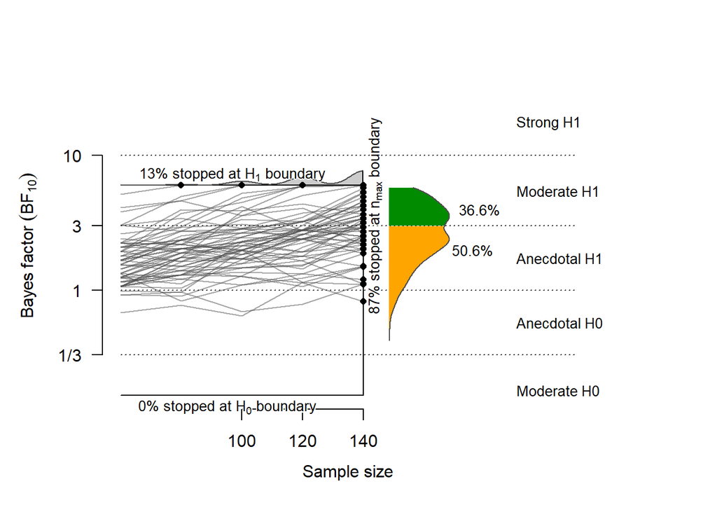

```r
plot(sim.H1_05, n.min=60, n.max = 140, boundary=c(1/6, 6))
```

### 4.3.2 Under H0

```r
BFDA.analyze(sim.H0_05, design="sequential", n.min=60, n.max=140, boundary=6)
```

```
##                                outcome percentage
## 1 Studies terminating at n.max (n=140)      99.2%
## 2    Studies terminating at a boundary       0.8%
## 3       --> Terminating at H1 boundary         0%
## 4       --> Terminating at H0 boundary       0.7%
##
## Of 99.2% of studies terminating at n.max (n=140):
## 1.5% showed evidence for H1 (BF > 3)
## 91.5% were inconclusive (3 > BF > 1/3)
## 6.3% showed evidence for H0 (BF < 1/3)
##
## Average sample number (ASN) at stopping point (both boundary hits and n.max): n = 140
##
## Sample number quantiles (50/80/90/95%) at stopping point:
## 50% 80% 90% 95%
## 140 140 140 140
```

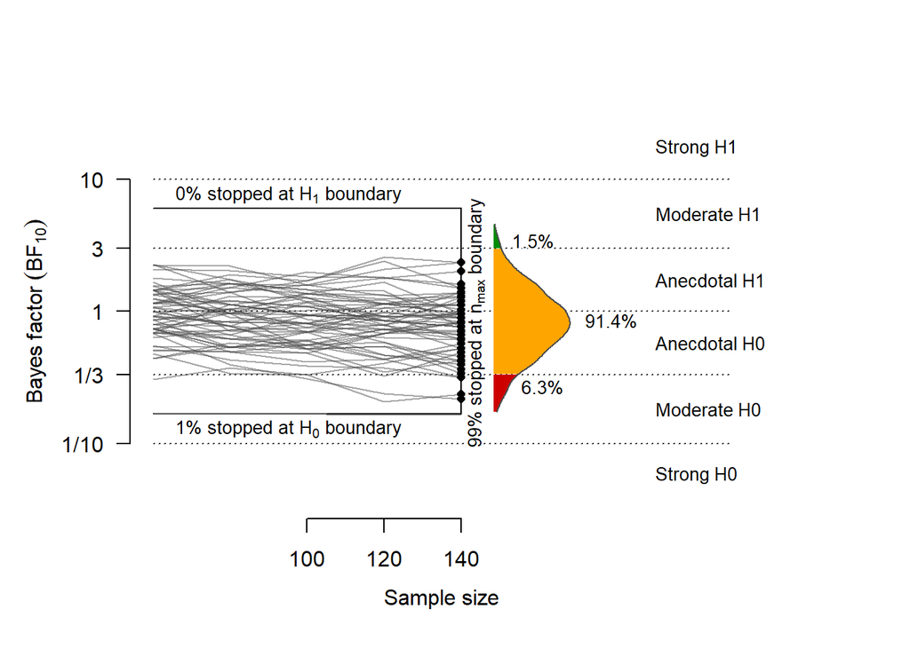

```r
plot(sim.H0_05, n.min=60, n.max=140, boundary=c(1/6, 6))
```

## 4.4 Find N to achieve power = .80

The N necessary to achieve 80% power is way out there (not even on the map)!

```r
SSD(sim.H1_05, power=.80, boundary=c(1/6, 6))
```

```
## A >= 80% (actual: NA%) power achieved at n = NA
## This setting implies long-term rates of:
## NA% inconclusive results and
##    NA% false-negative results.
```

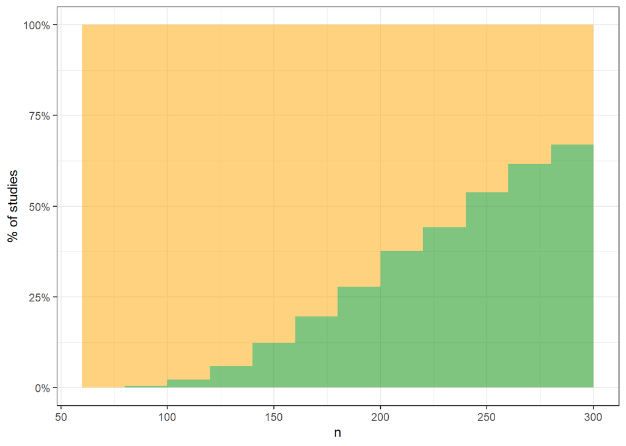

# 5 BFDA using a *minimum effect size of interest* + default prior

Same as previous, but we use the default prior, i.e. a standard normal $N(0,1)$.

## 5.1 Simulate hypothetical studies under *minimum effect size* and default prior

```r
# We use `type = "abtest"` for the binomial model.
# # Under alternative hypothesis H1
# sim.H1_05_defprior <- BFDA.sim(expected.ES = 0.5,  # minimum ES of interest
#                       type = "abtest",
#                       prior=list("normal", list(prior.mean = 0, prior.variance = 1)),
#                       options.sample = list(effecttype = "logOR"),
#                       n.min=60, n.max=300, stepsize = 20, boundary=Inf,
#                       alternative="greater",
#                       B=2000, verbose=TRUE, cores=1)

# [1] "Simulation started at 2019-08-14 14:34:42"
# [1] "Simulation finished at 2019-08-14 14:45:50"
# Duration: Time difference of 11.13938 mins

# Save/load to/from disk:

# write_rds(sim.H1_05_defprior, "sims_etc/sim_H1_05_defprior.rds")
sim.H1_05_defprior <- read_rds("sims_etc/sim_H1_05_defprior.rds")
sim.H1_05_defprior
```

```
##
## Bayes Factor Design Analysis
## --------------------------------
## Test type: abtest
## Number of simulations: 2000
## Stopping boundaries (evidential thresholds): 0; Inf
## Directionality of H1 analysis prior: greater
## Minimum n: 60
## Maximum n: 300
## Design: sequential
## Simulated true effect size (fixed): logOR = 0.5
```

```r
# # Under null hypothesis H0
# sim.H0_05_defprior <- BFDA.sim(expected.ES = 0,  # no effect
#                       type = "abtest",
#                       prior=list("normal", list(prior.mean = 0, prior.variance = 1)),
#                       options.sample = list(effecttype = "logOR"),
#                       n.min=60, n.max=300, stepsize = 20, boundary=Inf,
#                       alternative="greater",
#                       B=2000, verbose=TRUE, cores=1)

# [1] "Simulation started at 2019-08-14 14:46:53"
# [1] "Simulation finished at 2019-08-14 14:57:53"
# Duration: Time difference of 10.9876 mins

# Save/load to/from disk:

# write_rds(sim.H0_05_defprior, "sims_etc/sim_H0_05_defprior.rds")
sim.H0_05_defprior <- read_rds("sims_etc/sim_H0_05_defprior.rds")
sim.H0_05_defprior
```

```
##
## Bayes Factor Design Analysis
## --------------------------------
## Test type: abtest
## Number of simulations: 2000
## Stopping boundaries (evidential thresholds): 0; Inf
## Directionality of H1 analysis prior: greater
## Minimum n: 60
## Maximum n: 300
## Design: sequential
## Simulated true effect size (fixed): logOR = 0
```

## 5.2 Sequential design

### 5.2.1 Under H1

```r
BFDA.analyze(sim.H1_05_defprior, design="sequential", n.min=60, n.max=300, boundary=6)
```

```
##                                outcome percentage
## 1 Studies terminating at n.max (n=300)      16.2%
## 2    Studies terminating at a boundary      83.8%
## 3       --> Terminating at H1 boundary      82.2%
## 4       --> Terminating at H0 boundary       1.6%
##
## Of 16.2% of studies terminating at n.max (n=300):
## 4.5% showed evidence for H1 (BF > 3)
## 11.2% were inconclusive (3 > BF > 1/3)
## 0.6% showed evidence for H0 (BF < 1/3)
##
## Average sample number (ASN) at stopping point (both boundary hits and n.max): n = 165
##
## Sample number quantiles (50/80/90/95%) at stopping point:
## 50% 80% 90% 95%
## 140 280 300 300
```

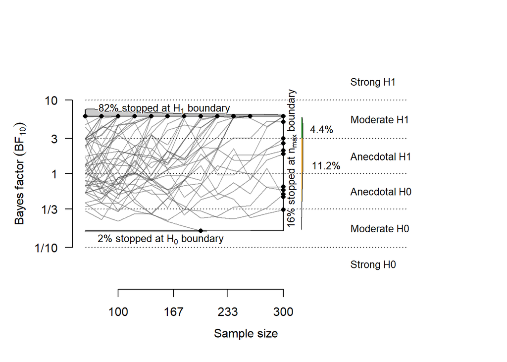

```r
plot(sim.H1_05_defprior, n.min=60, boundary=c(1/6, 6))
```

### 5.2.2 Under H0

```r
BFDA.analyze(sim.H0_05_defprior, design="sequential", n.min=60, n.max=300, boundary=6)
```

```
##                                outcome percentage
## 1 Studies terminating at n.max (n=300)        29%
## 2    Studies terminating at a boundary        71%
## 3       --> Terminating at H1 boundary         3%
## 4       --> Terminating at H0 boundary        68%
##
## Of 29% of studies terminating at n.max (n=300):
## 0.5% showed evidence for H1 (BF > 3)
## 15.4% were inconclusive (3 > BF > 1/3)
## 13.1% showed evidence for H0 (BF < 1/3)
##
## Average sample number (ASN) at stopping point (both boundary hits and n.max): n = 189
##
## Sample number quantiles (50/80/90/95%) at stopping point:
## 50% 80% 90% 95%
## 180 300 300 300
```

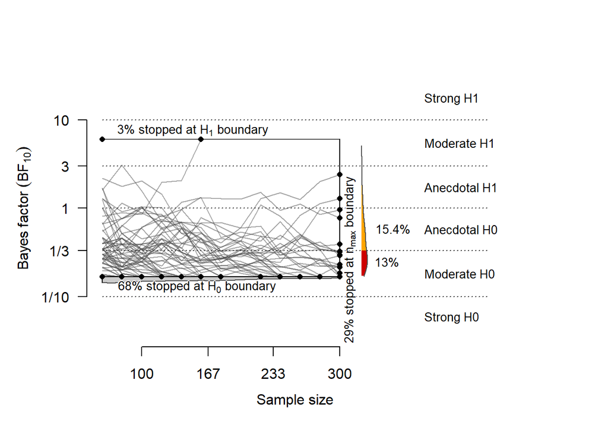

```r
plot(sim.H0_05_defprior, n.min=60, boundary=c(1/6, 6))
```

## 5.3 Sequential design with reasonable max N (=140)

### 5.3.1 Under H1

```r
BFDA.analyze(sim.H1_05_defprior, design="sequential", n.min=60, n.max=140, boundary=6)
```

```
##                                outcome percentage
## 1 Studies terminating at n.max (n=140)      47.6%
## 2    Studies terminating at a boundary      52.3%
## 3       --> Terminating at H1 boundary      51.2%
## 4       --> Terminating at H0 boundary       1.1%
##
## Of 47.6% of studies terminating at n.max (n=140):
## 7.2% showed evidence for H1 (BF > 3)
## 36.6% were inconclusive (3 > BF > 1/3)
## 3.8% showed evidence for H0 (BF < 1/3)
##
## Average sample number (ASN) at stopping point (both boundary hits and n.max): n = 114
##
## Sample number quantiles (50/80/90/95%) at stopping point:
## 50% 80% 90% 95%
## 140 140 140 140
```

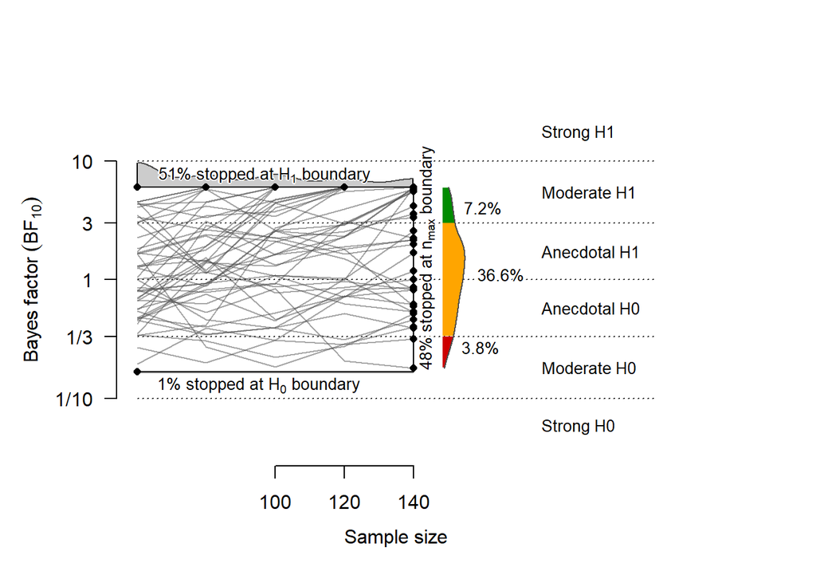

```r
plot(sim.H1_05_defprior, n.min=60, n.max=140, boundary=c(1/6, 6))
```

### 5.3.2 Under H0

```r
BFDA.analyze(sim.H0_05_defprior, design="sequential", n.min=60, n.max=140, boundary=6)
```

```
##                                outcome percentage
## 1 Studies terminating at n.max (n=140)      58.6%
## 2    Studies terminating at a boundary      41.4%
## 3       --> Terminating at H1 boundary       2.1%
## 4       --> Terminating at H0 boundary      39.2%
##
## Of 58.6% of studies terminating at n.max (n=140):
## 0.8% showed evidence for H1 (BF > 3)
## 28.9% were inconclusive (3 > BF > 1/3)
## 28.9% showed evidence for H0 (BF < 1/3)
##
## Average sample number (ASN) at stopping point (both boundary hits and n.max): n = 121
##
## Sample number quantiles (50/80/90/95%) at stopping point:
## 50% 80% 90% 95%
## 140 140 140 140
```

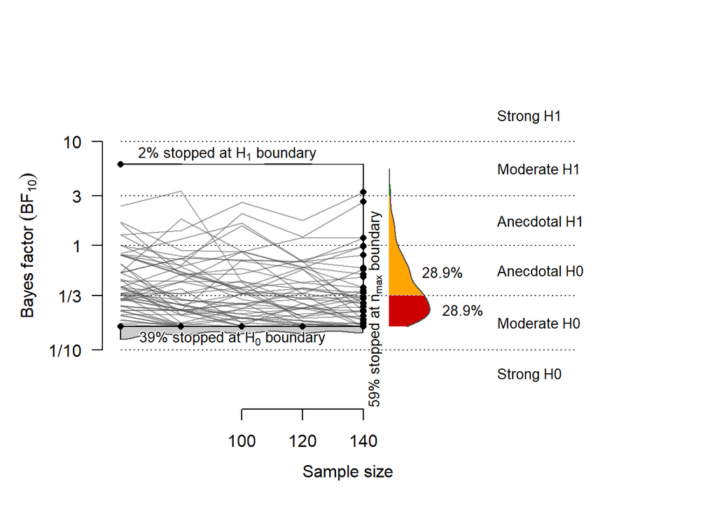

```r
plot(sim.H0_05_defprior, n.min=60, n.max=140, boundary=c(1/6, 6))
```

## 5.4 Find N to achieve power = .80

```r
SSD(sim.H1_05_defprior, power=.80, boundary=c(1/6, 6), alpha = 0.05)
```

```
## A >= 80% (actual: NA%) power achieved at n = NA
## This setting implies long-term rates of:
## NA% inconclusive results and
##    NA% false-negative results.
```

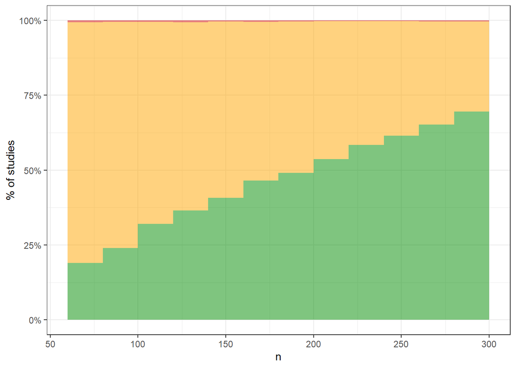

## 5.5 Conclusion

Startling result:

All inferences are *improved* when we use the default (uninformative) prior, compared to a prior based on the original study! (Compare this and the previous section.)

This goes against our intuitions: Disregarding any information about the prior leads to improved inferences *both* under H0 and H1. I suspect we don’t really understand what the prior is doing here…

# 6 Sanity check 1: BFDA using a *minimum effect size of interest* + prior.mean = ES

As a sanity check, run a simulation in which the mean of the prior is equal to the expected ES. We use the same variance as estimated from the model fit to the original data.

If inference under H1 is still worse in this case this would be very puzzling indeed.

## 6.1 Simulate hypothetical studies under *minimum effect size* and prior.mean = ES

```r
# # Under alternative hypothesis H1
# sim.H1_05_prior05 <- BFDA.sim(expected.ES = 0.5,  # minimum ES of interest
#                       type = "abtest",
#                       prior=list("normal", list(prior.mean = 0.5, prior.variance = var(beta_post))),
#                       options.sample = list(effecttype = "logOR"),
#                       n.min=60, n.max=300, stepsize = 20, boundary=Inf,
#                       alternative="greater",
#                       B=2000, verbose=TRUE, cores=1)
#
# # [1] "Simulation started at 2019-08-15 13:35:12"
# # [1] "Simulation finished at 2019-08-15 13:46:38"
# # Duration: Time difference of 11.42925 mins
#
# # Save to disk:
# write_rds(sim.H1_05_prior05, "sims_etc/sim_H1_05_prior05.rds")
```

```r
# Load from disk
sim.H1_05_prior05 <- read_rds("sims_etc/sim_H1_05_prior05.rds")
sim.H1_05_prior05
```

```
##
## Bayes Factor Design Analysis
## --------------------------------
## Test type: abtest
## Number of simulations: 2000
## Stopping boundaries (evidential thresholds): 0; Inf
## Directionality of H1 analysis prior: greater
## Minimum n: 60
## Maximum n: 300
## Design: sequential
## Simulated true effect size (fixed): logOR = 0.5
```

```r
# # Under null hypothesis H0
# sim.H0_05_prior05 <- BFDA.sim(expected.ES = 0,  # no effect
#                       type = "abtest",
#                       prior=list("normal", list(prior.mean = 0.5, prior.variance = var(beta_post))),
#                       options.sample = list(effecttype = "logOR"),
#                       n.min=60, n.max=300, stepsize = 20, boundary=Inf,
#                       alternative="greater",
#                       B=2000, verbose=TRUE, cores=1)
#
# # [1] "Simulation started at 2019-08-15 13:48:54"
# # [1] "Simulation finished at 2019-08-15 14:00:17"
# # Duration: Time difference of 11.38489 mins
#
# # Save to disk:
# write_rds(sim.H0_05_prior05, "sims_etc/sim_H0_05_prior05.rds")
```

```r
# Load from disk:
sim.H0_05_prior05 <- read_rds("sims_etc/sim_H0_05_prior05.rds")
sim.H0_05_prior05
```

```
##
## Bayes Factor Design Analysis
## --------------------------------
## Test type: abtest
## Number of simulations: 2000
## Stopping boundaries (evidential thresholds): 0; Inf
## Directionality of H1 analysis prior: greater
## Minimum n: 60
## Maximum n: 300
## Design: sequential
## Simulated true effect size (fixed): logOR = 0
```

## 6.2 Sequential design

### 6.2.1 Under H1

```r
BFDA.analyze(sim.H1_05_prior05, design="sequential", n.min=60, n.max=300, boundary=6)
```

```
##                                outcome percentage
## 1 Studies terminating at n.max (n=300)       4.2%
## 2    Studies terminating at a boundary      95.8%
## 3       --> Terminating at H1 boundary        88%
## 4       --> Terminating at H0 boundary       7.8%
##
## Of 4.2% of studies terminating at n.max (n=300):
## 1.4% showed evidence for H1 (BF > 3)
## 2.5% were inconclusive (3 > BF > 1/3)
## 0.4% showed evidence for H0 (BF < 1/3)
##
## Average sample number (ASN) at stopping point (both boundary hits and n.max): n = 126
##
## Sample number quantiles (50/80/90/95%) at stopping point:
## 50% 80% 90% 95%
## 100 180 240 300
```

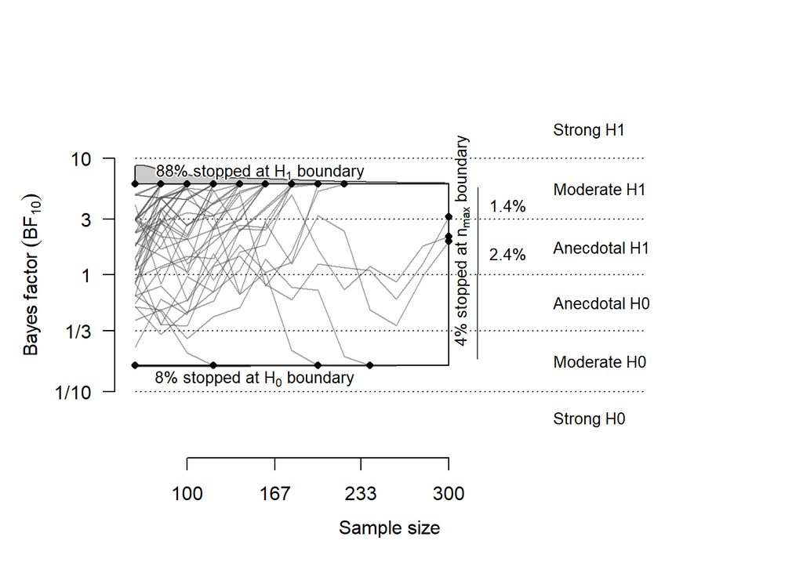

```r
plot(sim.H1_05_prior05, n.min=60, boundary=c(1/6, 6))
```

### 6.2.2 Under H0

```r
BFDA.analyze(sim.H0_05_prior05, design="sequential", n.min=60, n.max=300, boundary=6)
```

```
##                                outcome percentage
## 1 Studies terminating at n.max (n=300)       4.5%
## 2    Studies terminating at a boundary      95.5%
## 3       --> Terminating at H1 boundary       7.5%
## 4       --> Terminating at H0 boundary      87.9%
##
## Of 4.5% of studies terminating at n.max (n=300):
## 0.2% showed evidence for H1 (BF > 3)
## 3.2% were inconclusive (3 > BF > 1/3)
## 1.1% showed evidence for H0 (BF < 1/3)
##
## Average sample number (ASN) at stopping point (both boundary hits and n.max): n = 125
##
## Sample number quantiles (50/80/90/95%) at stopping point:
## 50% 80% 90% 95%
## 100 180 240 300
```

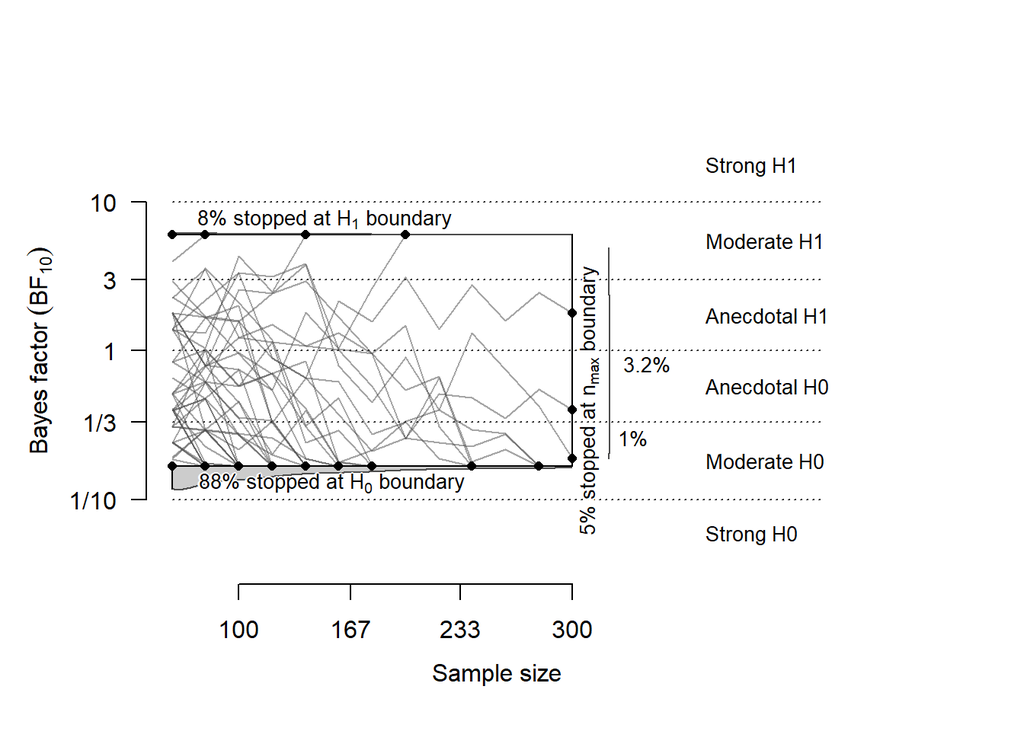

```r
plot(sim.H0_05_prior05, n.min=60, boundary=c(1/6, 6))
```

## 6.3 Sequential design with reasonable max N (=140)

### 6.3.1 Under H1

```r
BFDA.analyze(sim.H1_05_prior05, design="sequential", n.min=60, n.max=140, boundary=6)
```

```
##                                outcome percentage
## 1 Studies terminating at n.max (n=140)      29.5%
## 2    Studies terminating at a boundary      70.5%
## 3       --> Terminating at H1 boundary      64.5%
## 4       --> Terminating at H0 boundary       5.9%
##
## Of 29.5% of studies terminating at n.max (n=140):
## 8.6% showed evidence for H1 (BF > 3)
## 18.8% were inconclusive (3 > BF > 1/3)
## 2.1% showed evidence for H0 (BF < 1/3)
##
## Average sample number (ASN) at stopping point (both boundary hits and n.max): n = 102
##
## Sample number quantiles (50/80/90/95%) at stopping point:
## 50% 80% 90% 95%
## 100 140 140 140
```

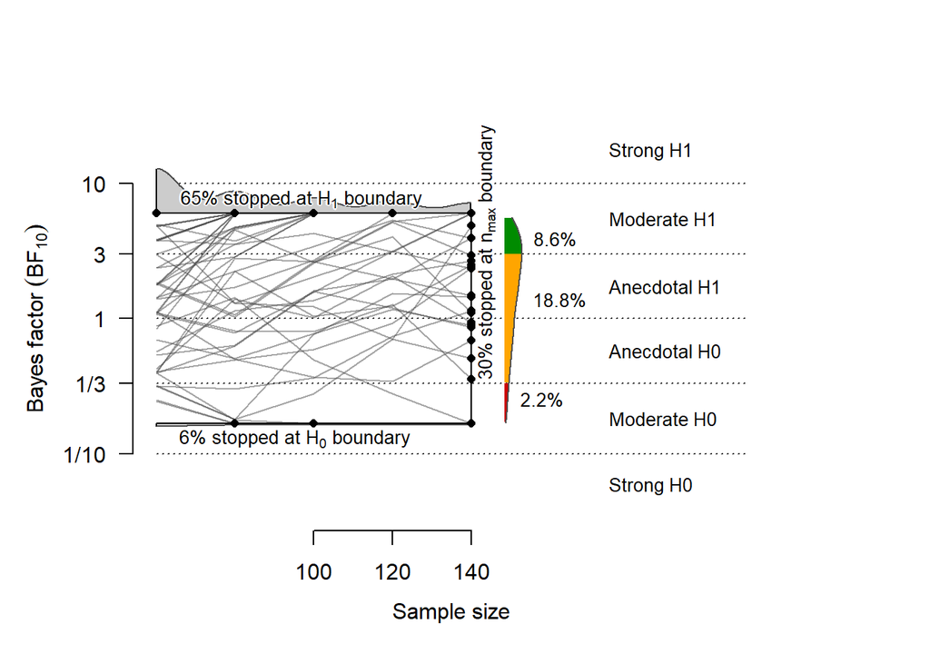

```r
plot(sim.H1_05_prior05, n.min=60, n.max=140, boundary=c(1/6, 6))
```

### 6.3.2 Under H0

```r
BFDA.analyze(sim.H0_05_prior05, design="sequential", n.min=60, n.max=140, boundary=6)
```

```
##                                outcome percentage
## 1 Studies terminating at n.max (n=140)      28.3%
## 2    Studies terminating at a boundary      71.7%
## 3       --> Terminating at H1 boundary       5.5%
## 4       --> Terminating at H0 boundary      66.1%
##
## Of 28.3% of studies terminating at n.max (n=140):
## 1.2% showed evidence for H1 (BF > 3)
## 18.8% were inconclusive (3 > BF > 1/3)
## 8.3% showed evidence for H0 (BF < 1/3)
##
## Average sample number (ASN) at stopping point (both boundary hits and n.max): n = 102
##
## Sample number quantiles (50/80/90/95%) at stopping point:
## 50% 80% 90% 95%
## 100 140 140 140
```

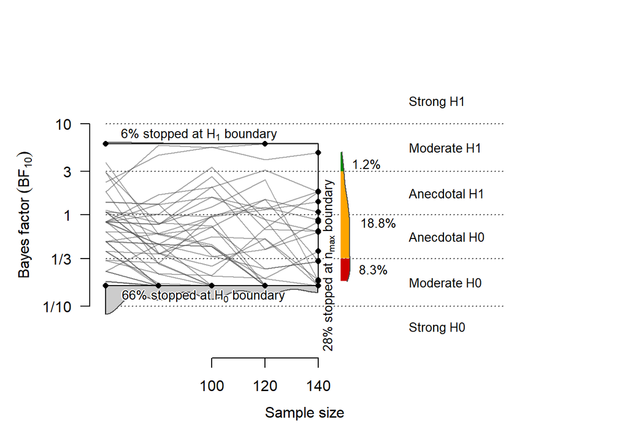

```r
plot(sim.H0_05_prior05, n.min=60, n.max=140, boundary=c(1/6, 6))
```

## 6.4 Find N to achieve power = .80

```r
SSD(sim.H1_05_prior05, power=.80, boundary=c(1/6, 6))
```

```
## A >= 80% (actual: 83.3%) power achieved at n = 300
## This setting implies long-term rates of:
## 14.9% inconclusive results and
##    1.8% false-negative results.
```

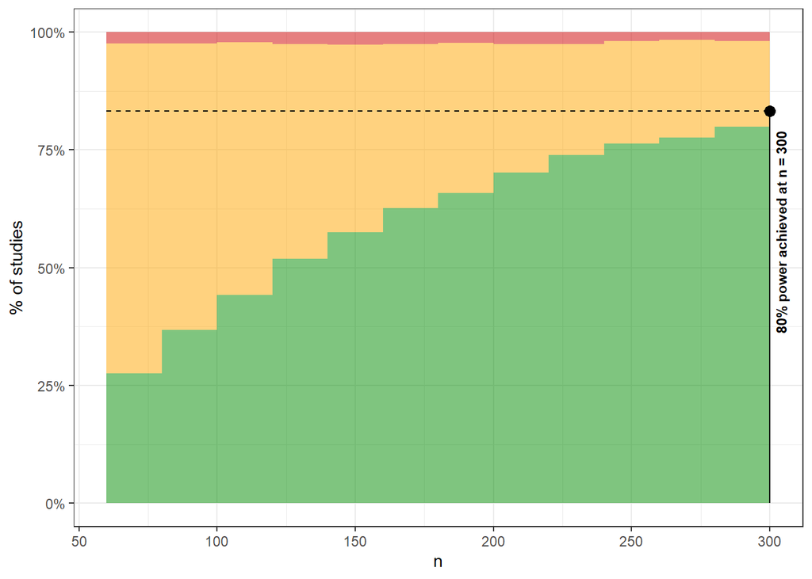

## 6.5 Conclusion

# 7 Sanity check 2: BFDA using a *minimum effect size of interest* + prior.mean = ES + Var = 1

As a 2nd sanity check, run a simulation like the previous one but with a more reasonable variance on the prior (i.e., 1).

## 7.1 Simulate hypothetical studies

```r
# # Under alternative hypothesis H1
# sim.H1_05_prior05_var1 <- BFDA.sim(expected.ES = 0.5,  # minimum ES of interest
#                       type = "abtest",
#                       prior=list("normal", list(prior.mean = 0.5, prior.variance = 1)),
#                       options.sample = list(effecttype = "logOR"),
#                       n.min=60, n.max=300, stepsize = 20, boundary=Inf,
#                       alternative="greater",
#                       B=2000, verbose=TRUE, cores=1)
#
# # [1] "Simulation started at 2019-08-15 14:23:24"
# # [1] "Simulation finished at 2019-08-15 14:34:59"
# # Duration: Time difference of 11.58677 mins
#
# # Save to disk:
# write_rds(sim.H1_05_prior05_var1, "sims_etc/sim_H1_05_prior05_var1.rds")
```

```r
# Load from disk
sim.H1_05_prior05_var1 <- read_rds("sims_etc/sim_H1_05_prior05_var1.rds")
sim.H1_05_prior05_var1
```

```
##
## Bayes Factor Design Analysis
## --------------------------------
## Test type: abtest
## Number of simulations: 2000
## Stopping boundaries (evidential thresholds): 0; Inf
## Directionality of H1 analysis prior: greater
## Minimum n: 60
## Maximum n: 300
## Design: sequential
## Simulated true effect size (fixed): logOR = 0.5
```

```r
# # Under null hypothesis H0
# sim.H0_05_prior05_var1 <- BFDA.sim(expected.ES = 0,  # no effect
#                       type = "abtest",
#                       prior=list("normal", list(prior.mean = 0.5, prior.variance = 1)),
#                       options.sample = list(effecttype = "logOR"),
#                       n.min=60, n.max=300, stepsize = 20, boundary=Inf,
#                       alternative="greater",
#                       B=2000, verbose=TRUE, cores=1)
#
# # [1] "Simulation started at 2019-08-15 14:35:45"
# # [1] "Simulation finished at 2019-08-15 14:47:29"
# # Duration: Time difference of 11.73509 mins
#
# # Save to disk:
# write_rds(sim.H0_05_prior05_var1, "sims_etc/sim_H0_05_prior05_var1.rds")
```

```r
# Load from disk:
sim.H0_05_prior05_var1 <- read_rds("sims_etc/sim_H0_05_prior05_var1.rds")
sim.H0_05_prior05_var1
```

```
##
## Bayes Factor Design Analysis
## --------------------------------
## Test type: abtest
## Number of simulations: 2000
## Stopping boundaries (evidential thresholds): 0; Inf
## Directionality of H1 analysis prior: greater
## Minimum n: 60
## Maximum n: 300
## Design: sequential
## Simulated true effect size (fixed): logOR = 0
```

## 7.2 Sequential design

### 7.2.1 Under H1

```r
BFDA.analyze(sim.H1_05_prior05_var1, design="sequential", n.min=60, n.max=300, boundary=6)
```

```
##                                outcome percentage
## 1 Studies terminating at n.max (n=300)      15.4%
## 2    Studies terminating at a boundary      84.5%
## 3       --> Terminating at H1 boundary      78.6%
## 4       --> Terminating at H0 boundary       5.9%
##
## Of 15.4% of studies terminating at n.max (n=300):
## 3.6% showed evidence for H1 (BF > 3)
## 11.3% were inconclusive (3 > BF > 1/3)
## 0.4% showed evidence for H0 (BF < 1/3)
##
## Average sample number (ASN) at stopping point (both boundary hits and n.max): n = 164
##
## Sample number quantiles (50/80/90/95%) at stopping point:
## 50% 80% 90% 95%
## 140 280 300 300
```

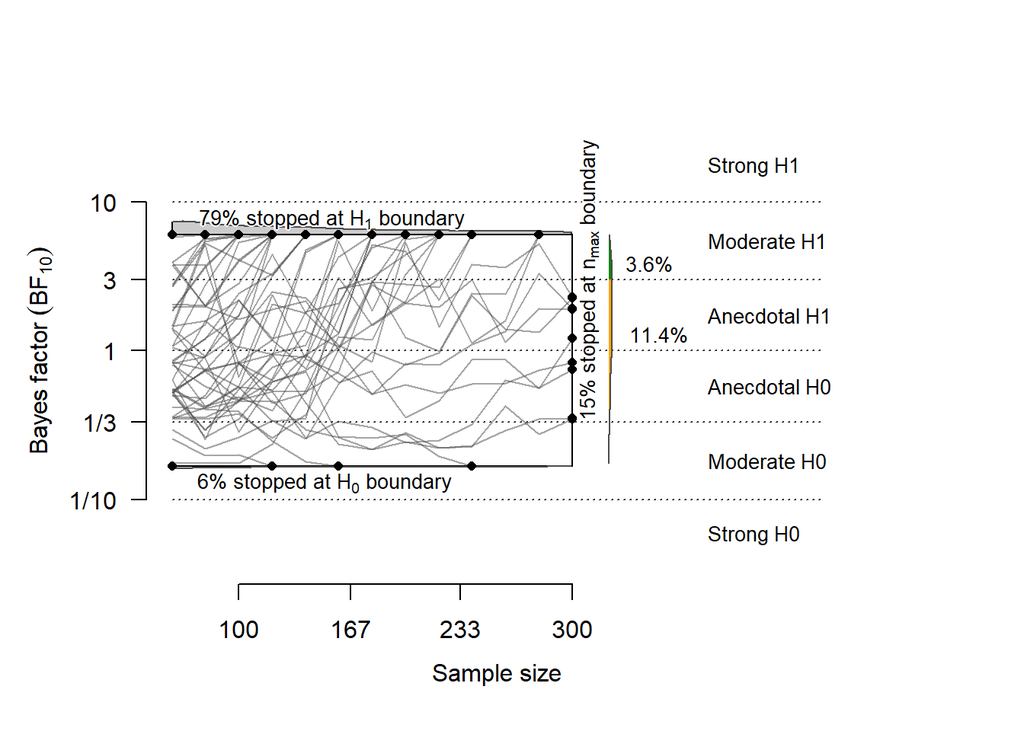

```r
plot(sim.H1_05_prior05_var1, n.min=60, boundary=c(1/6, 6))
```

### 7.2.2 Under H0

```r
BFDA.analyze(sim.H0_05_prior05_var1, design="sequential", n.min=60, n.max=300, boundary=6)
```

```
##                                outcome percentage
## 1 Studies terminating at n.max (n=300)      15.5%
## 2    Studies terminating at a boundary      84.5%
## 3       --> Terminating at H1 boundary       2.5%
## 4       --> Terminating at H0 boundary        82%
##
## Of 15.5% of studies terminating at n.max (n=300):
## 0.4% showed evidence for H1 (BF > 3)
## 8.9% were inconclusive (3 > BF > 1/3)
## 6.2% showed evidence for H0 (BF < 1/3)
##
## Average sample number (ASN) at stopping point (both boundary hits and n.max): n = 145
##
## Sample number quantiles (50/80/90/95%) at stopping point:
## 50% 80% 90% 95%
## 100 260 300 300
```

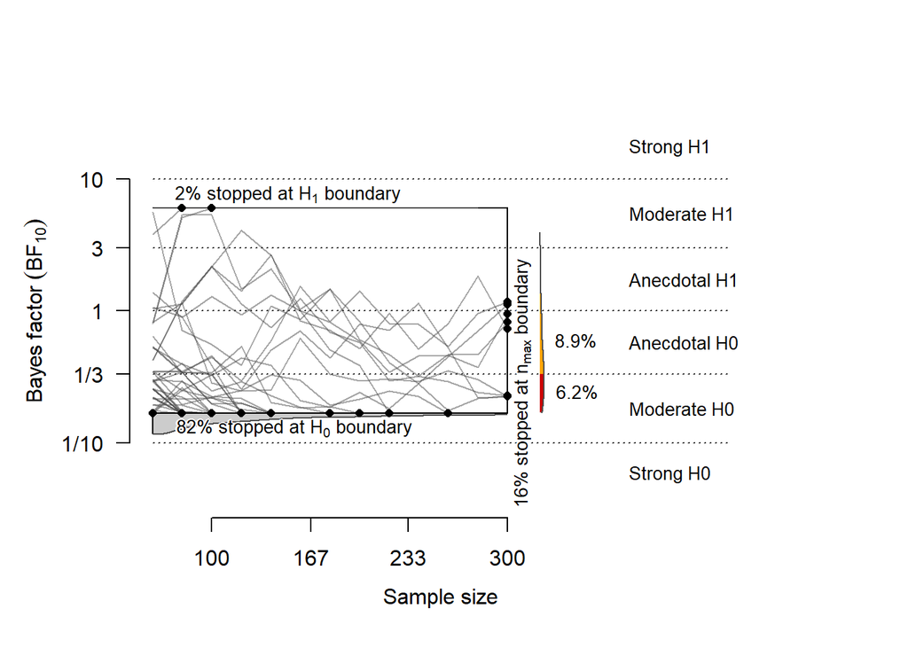

```r
plot(sim.H0_05_prior05_var1, n.min=60, boundary=c(1/6, 6))
```

## 7.3 Sequential design with reasonable max N (=140)

### 7.3.1 Under H1

```r
BFDA.analyze(sim.H1_05_prior05_var1, design="sequential", n.min=60, n.max=140, boundary=6)
```

```
##                                outcome percentage
## 1 Studies terminating at n.max (n=140)      46.3%
## 2    Studies terminating at a boundary      53.7%
## 3       --> Terminating at H1 boundary      48.8%
## 4       --> Terminating at H0 boundary         5%
##
## Of 46.3% of studies terminating at n.max (n=140):
## 5.5% showed evidence for H1 (BF > 3)
## 35.9% were inconclusive (3 > BF > 1/3)
## 4.9% showed evidence for H0 (BF < 1/3)
##
## Average sample number (ASN) at stopping point (both boundary hits and n.max): n = 114
##
## Sample number quantiles (50/80/90/95%) at stopping point:
## 50% 80% 90% 95%
## 140 140 140 140
```

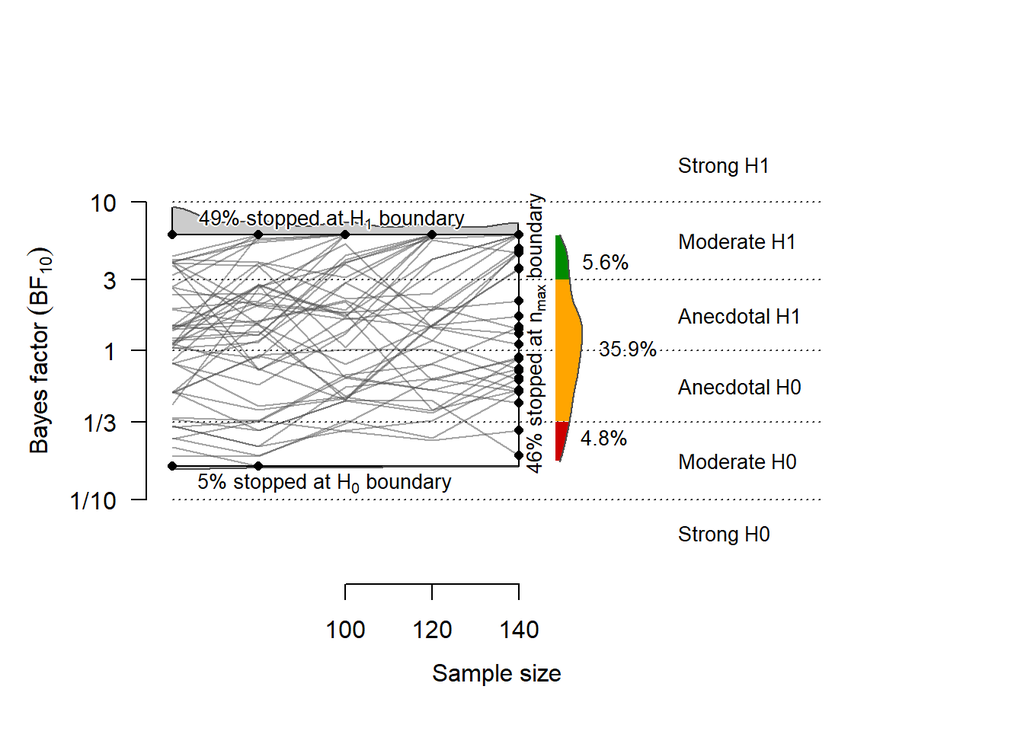

```r
plot(sim.H1_05_prior05_var1, n.min=60, n.max=140, boundary=c(1/6, 6))
```

### 7.3.2 Under H0

```r
BFDA.analyze(sim.H0_05_prior05_var1, design="sequential", n.min=60, n.max=140, boundary=6)
```

```
##                                outcome percentage
## 1 Studies terminating at n.max (n=140)        36%
## 2    Studies terminating at a boundary        64%
## 3       --> Terminating at H1 boundary       1.9%
## 4       --> Terminating at H0 boundary      62.1%
##
## Of 36% of studies terminating at n.max (n=140):
## 0.4% showed evidence for H1 (BF > 3)
## 18.8% were inconclusive (3 > BF > 1/3)
## 16.9% showed evidence for H0 (BF < 1/3)
##
## Average sample number (ASN) at stopping point (both boundary hits and n.max): n = 105
##
## Sample number quantiles (50/80/90/95%) at stopping point:
## 50% 80% 90% 95%
## 100 140 140 140
```

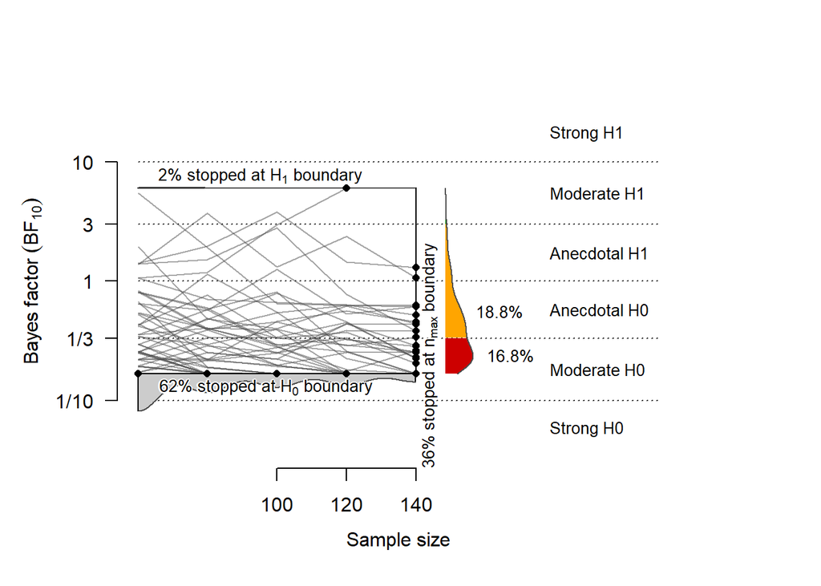

```r
plot(sim.H0_05_prior05_var1, n.min=60, n.max=140, boundary=c(1/6, 6))
```

## 7.4 Find N to achieve power = .80

The N necessary to achieve 80% power is way out there (not even on the map)!

```r
SSD(sim.H1_05_prior05_var1, power=.80, boundary=c(1/6, 6))
```

```
## A >= 80% (actual: NA%) power achieved at n = NA
## This setting implies long-term rates of:
## NA% inconclusive results and
##    NA% false-negative results.
```

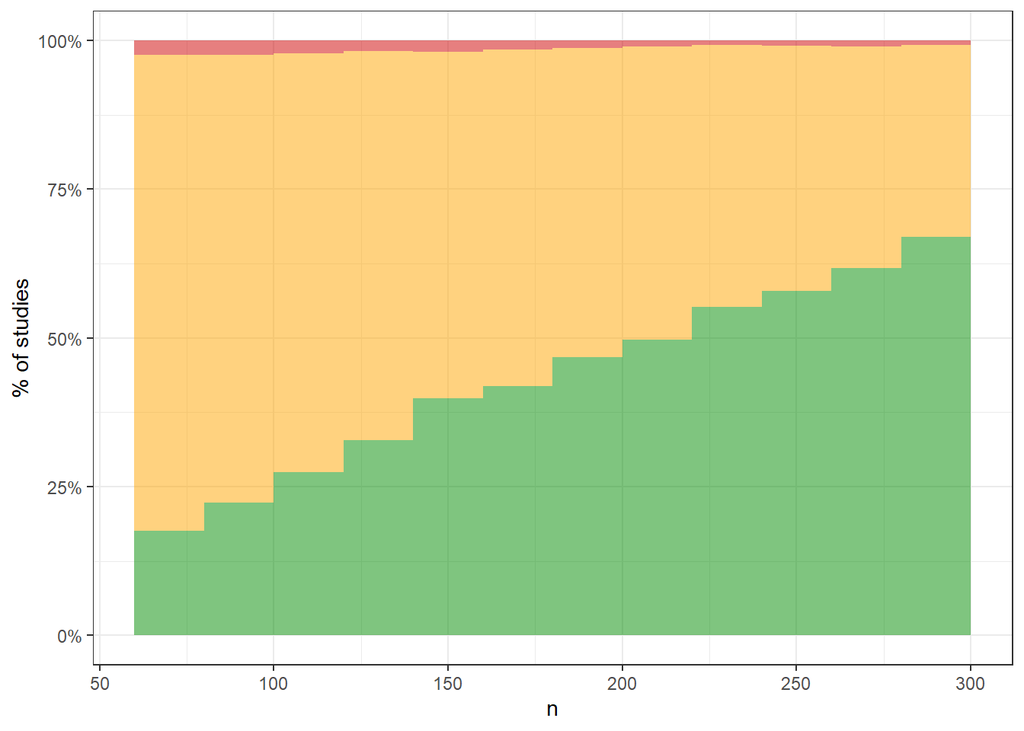

## 7.5 Conclusion

# 8 Simulations for letter to Cortex editors

We run simulations with much higher N to get at what N we would actually need to plan for compelling evidence.

We run two simulations, both with `expected.ES` equal to the posterior from our re-analysis of the SP13 data.

Only the `prior` argument varies, with the following two options:

1. A non-informative default prior (to convince a “skeptical audience”, see SW18).
2. A prior that is equal to the posterior distribution based on original results.

## 8.1 Simulate hypothetical studies

For each of the settings for prior, simulate data under H1 and H0 and save to disk:

```r
# ## Non-informative (default) prior:
#
# # Under alternative hypothesis H1
# sim.H1_origES_defPrior <- BFDA.sim(
#   expected.ES = beta_post,  # posterior of original becomes prior
#   type = "abtest",
#   prior=list("normal", list(prior.mean = 0, prior.variance = 1)),
#   options.sample = list(effecttype = "logOR"),
#   n.min=100, n.max=3000, stepsize = 100, boundary=Inf,
#   alternative="greater",
#   B=1000, verbose=TRUE, cores=1)
#
# # [1] "Simulation started at 2019-08-16 10:05:21"
# # [1] "Simulation finished at 2019-08-16 10:13:21"
# # Duration: Time difference of 8.008386 mins
#
# # Save to disk:
# write_rds(sim.H1_origES_defPrior, "sims_etc/sim_H1_origES_defPrior.rds")
#
# # Under null hypothesis H0
# sim.H0_origES_defPrior <- BFDA.sim(
#   expected.ES = 0,  # no effect
#   type = "abtest",
#   prior=list("normal", list(prior.mean = 0, prior.variance = 1)),
#   options.sample = list(effecttype = "logOR"),
#   n.min=100, n.max=3000, stepsize = 100, boundary=Inf,
#   alternative="greater",
#   B=1000, verbose=TRUE, cores=1)
#
# # [1] "Simulation started at 2019-08-16 10:13:22"
# # [1] "Simulation finished at 2019-08-16 10:21:19"
# # Duration: Time difference of 7.956102 mins
#
# # Save to disk:
# write_rds(sim.H0_origES_defPrior, "sims_etc/sim_H0_origES_defPrior.rds")
#
#
# ## Informed prior (based on results in SP13):
#
# # Under alternative hypothesis H1
# sim.H1_origES_origPrior <- BFDA.sim(
#   expected.ES = beta_post,  # posterior of original becomes prior
#   type = "abtest",
#   prior=list("normal", list(prior.mean = mean(beta_post), prior.variance = var(beta_post))),
#   options.sample = list(effecttype = "logOR"),
#   n.min=100, n.max=3000, stepsize = 100, boundary=Inf,
#   alternative="greater",
#   B=1000, verbose=TRUE, cores=1)
#
# # [1] "Simulation started at 2019-08-16 10:21:19"
# # [1] "Simulation finished at 2019-08-16 10:29:42"
# # Duration: Time difference of 8.379531 mins
#
# # Save to disk:
# write_rds(sim.H1_origES_origPrior, "sims_etc/sim_H1_origES_origPrior.rds")
#
# # Under null hypothesis H0
# sim.H0_origES_origPrior <- BFDA.sim(
#   expected.ES = 0,  # no effect
#   type = "abtest",
#   prior=list("normal", list(prior.mean = mean(beta_post), prior.variance = var(beta_post))),
#   options.sample = list(effecttype = "logOR"),
#   n.min=100, n.max=3000, stepsize = 100, boundary=Inf,
#   alternative="greater",
#   B=1000, verbose=TRUE, cores=1)
#
# # [1] "Simulation started at 2019-08-16 10:29:43"
# # [1] "Simulation finished at 2019-08-16 10:38:06"
# # Duration: Time difference of 8.385818 mins
#
# # Save to disk:
# write_rds(sim.H0_origES_origPrior, "sims_etc/sim_H0_origES_origPrior.rds")
```

Load from disk

```r
# Load from disk
sim.H1_origES_defPrior <- read_rds("sims_etc/sim_H1_origES_defPrior.rds")
sim.H1_origES_defPrior
```

```
##
## Bayes Factor Design Analysis
## --------------------------------
## Test type: abtest
## Number of simulations: 1000
## Stopping boundaries (evidential thresholds): 0; Inf
## Directionality of H1 analysis prior: greater
## Minimum n: 100
## Maximum n: 3000
## Design: sequential
## Simulated true effect size (random): logOR = 0.15; 25%/75% quantile = [0.12; 0.18]
```

```r
sim.H0_origES_defPrior <- read_rds("sims_etc/sim_H0_origES_defPrior.rds")
sim.H0_origES_defPrior
```

```
##
## Bayes Factor Design Analysis
## --------------------------------
## Test type: abtest
## Number of simulations: 1000
## Stopping boundaries (evidential thresholds): 0; Inf
## Directionality of H1 analysis prior: greater
## Minimum n: 100
## Maximum n: 3000
## Design: sequential
## Simulated true effect size (fixed): logOR = 0
```

```r
sim.H1_origES_origPrior <- read_rds("sims_etc/sim_H1_origES_origPrior.rds")
sim.H1_origES_origPrior
```

```
##
## Bayes Factor Design Analysis
## --------------------------------
## Test type: abtest
## Number of simulations: 1000
## Stopping boundaries (evidential thresholds): 0; Inf
## Directionality of H1 analysis prior: greater
## Minimum n: 100
## Maximum n: 3000
## Design: sequential
## Simulated true effect size (random): logOR = 0.15; 25%/75% quantile = [0.12; 0.18]
```

```r
sim.H0_origES_origPrior <- read_rds("sims_etc/sim_H0_origES_origPrior.rds")
sim.H0_origES_origPrior
```

```
##
## Bayes Factor Design Analysis
## --------------------------------
## Test type: abtest
## Number of simulations: 1000
## Stopping boundaries (evidential thresholds): 0; Inf
## Directionality of H1 analysis prior: greater
## Minimum n: 100
## Maximum n: 3000
## Design: sequential
## Simulated true effect size (fixed): logOR = 0
```

## 8.2 Sequential design

### 8.2.1 Under H1

Default prior:

```r
BFDA.analyze(sim.H1_origES_defPrior, design="sequential", n.min=100, n.max=3000, boundary=6)
```

```
##                                 outcome percentage
## 1 Studies terminating at n.max (n=3000)       5.5%
## 2     Studies terminating at a boundary      94.5%
## 3        --> Terminating at H1 boundary      48.2%
## 4        --> Terminating at H0 boundary      46.3%
##
## Of 5.5% of studies terminating at n.max (n=3000):
## 1% showed evidence for H1 (BF > 3)
## 4% were inconclusive (3 > BF > 1/3)
## 0.5% showed evidence for H0 (BF < 1/3)
##
## Average sample number (ASN) at stopping point (both boundary hits and n.max): n = 850
##
## Sample number quantiles (50/80/90/95%) at stopping point:
##  50%  80%  90%  95%
##  500 1400 2400 3000
```

Informed prior:

```r
BFDA.analyze(sim.H1_origES_origPrior, design="sequential", n.min=100, n.max=3000, boundary=6)
```

```
##                                 outcome percentage
## 1 Studies terminating at n.max (n=3000)       5.6%
## 2     Studies terminating at a boundary      94.4%
## 3        --> Terminating at H1 boundary      81.8%
## 4        --> Terminating at H0 boundary      12.6%
##
## Of 5.6% of studies terminating at n.max (n=3000):
## 1.2% showed evidence for H1 (BF > 3)
## 4.1% were inconclusive (3 > BF > 1/3)
## 0.3% showed evidence for H0 (BF < 1/3)
##
## Average sample number (ASN) at stopping point (both boundary hits and n.max): n = 1142
##
## Sample number quantiles (50/80/90/95%) at stopping point:
##  50%  80%  90%  95%
##  900 1700 2300 3000
```

Default:

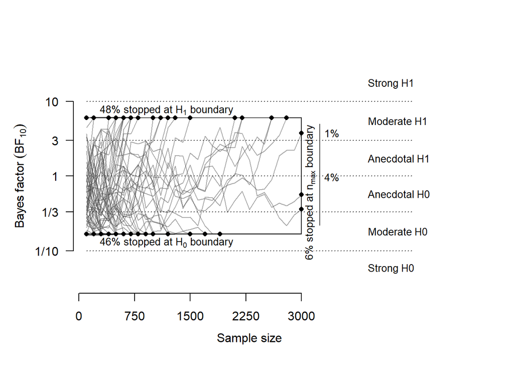

```r
plot(sim.H1_origES_defPrior, n.min=100, boundary=c(1/6, 6))
```

Informed:

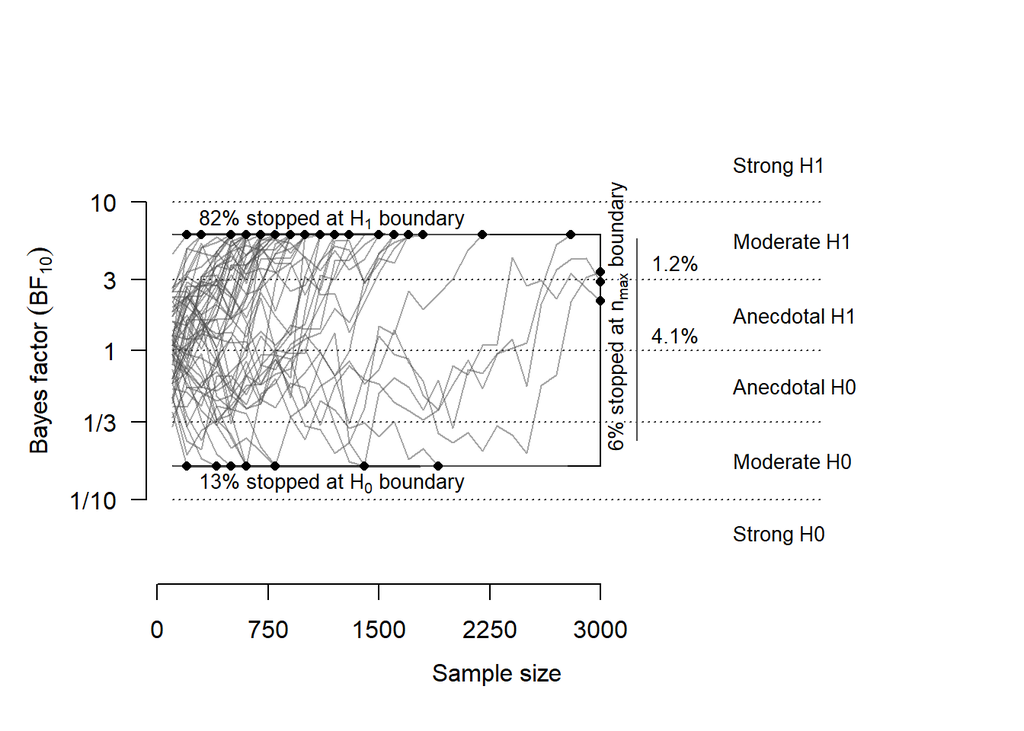

```r
plot(sim.H1_origES_origPrior, n.min=100, boundary=c(1/6, 6))
```

### 8.2.2 Under H0

Default:

```r
BFDA.analyze(sim.H0_origES_defPrior, design="sequential", n.min=100, n.max=3000, boundary=6)
```

```
##                                 outcome percentage
## 1 Studies terminating at n.max (n=3000)         1%
## 2     Studies terminating at a boundary        99%
## 3        --> Terminating at H1 boundary       2.9%
## 4        --> Terminating at H0 boundary      96.1%
##
## Of 1% of studies terminating at n.max (n=3000):
## 0% showed evidence for H1 (BF > 3)
## 0.7% were inconclusive (3 > BF > 1/3)
## 0.3% showed evidence for H0 (BF < 1/3)
##
## Average sample number (ASN) at stopping point (both boundary hits and n.max): n = 452
##
## Sample number quantiles (50/80/90/95%) at stopping point:
##  50%  80%  90%  95%
##  300  600 1000 1500
```

Informed

```r
BFDA.analyze(sim.H0_origES_origPrior, design="sequential", n.min=100, n.max=3000, boundary=6)
```

```
##                                 outcome percentage
## 1 Studies terminating at n.max (n=3000)       5.2%
## 2     Studies terminating at a boundary      94.8%
## 3        --> Terminating at H1 boundary        10%
## 4        --> Terminating at H0 boundary      84.8%
##
## Of 5.2% of studies terminating at n.max (n=3000):
## 0.5% showed evidence for H1 (BF > 3)
## 3.4% were inconclusive (3 > BF > 1/3)
## 1.3% showed evidence for H0 (BF < 1/3)
##
## Average sample number (ASN) at stopping point (both boundary hits and n.max): n = 1210
##
## Sample number quantiles (50/80/90/95%) at stopping point:
##  50%  80%  90%  95%
## 1000 1800 2400 3000
```

Default:

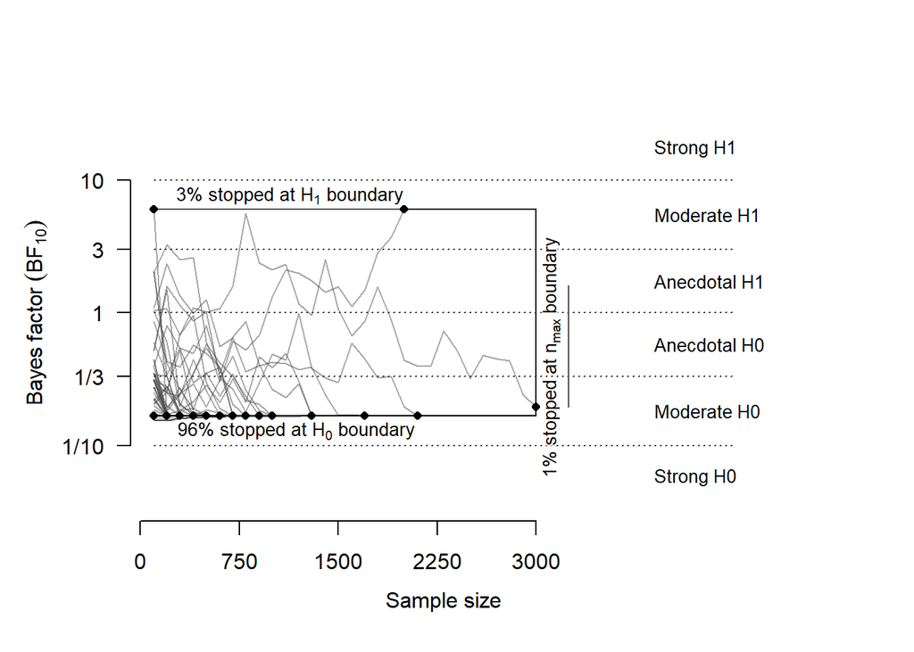

```r
plot(sim.H0_origES_defPrior, n.min=100, boundary=c(1/6, 6))
```

Informed:

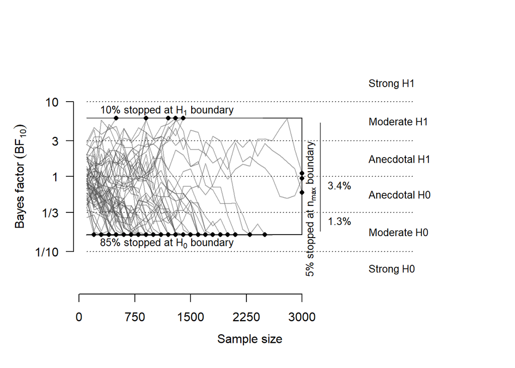

```r
plot(sim.H0_origES_origPrior, n.min=100, boundary=c(1/6, 6))
```

## 8.3 Find N to achieve power = .80

### 8.3.1 For H1

With default prior:

```r
SSD(sim.H1_origES_defPrior, power=.80, boundary=c(1/6, 6))
```

```
## A >= 80% (actual: NA%) power achieved at n = NA
## This setting implies long-term rates of:
## NA% inconclusive results and
##    NA% false-negative results.
```

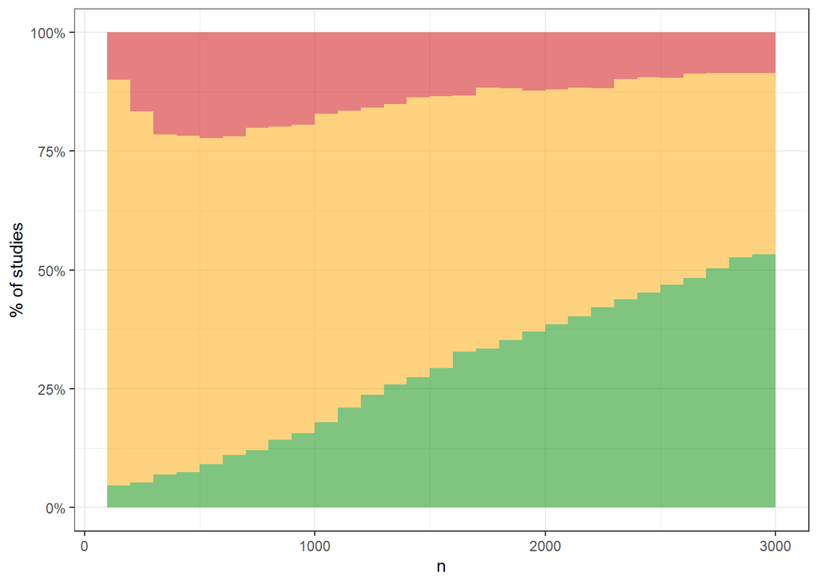

With informed prior:

```r
SSD(sim.H1_origES_origPrior, power=.80, boundary=c(1/6, 6))
```

```
## A >= 80% (actual: NA%) power achieved at n = NA
## This setting implies long-term rates of:
## NA% inconclusive results and
##    NA% false-negative results.
```

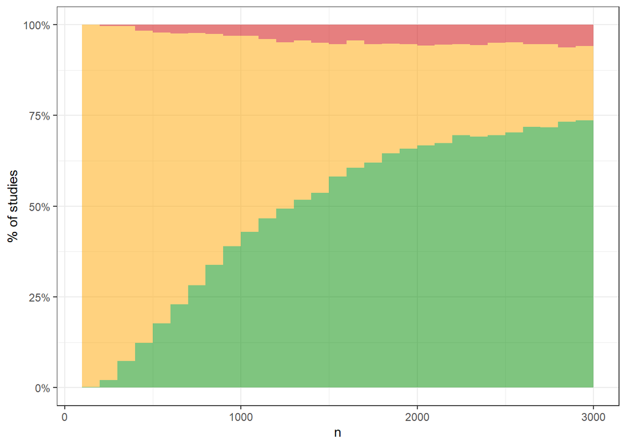